# Biostat 203B Homework 5

Due Mar 20 @ 11:59PM

Author

zhengda wang (905788829)

## Data preprocessing & Partition

```r
library(GGally)
library(ranger)
library(stacks)
library(keras)
library(gtsummary)
library(tidyverse)
library(tidymodels)
library(vip)
mimiciv_icu_cohort <- readRDS("mimiciv_shiny/mimic_icu_cohort.rds") %>%
  mutate(
    gender = as.character(gender),
    insurance = as.character(insurance),
    marital_status = as.character(marital_status),
    first_careunit = as.character(first_careunit),
    los_long = as.factor(los_long)
  )
# Due to a significant amount of missing data in the 'last lab
# measurements before the ICU stay' section, only the
# rows with data in these columns will be retained
mimiciv_icu_cohort <- mimiciv_icu_cohort[complete.cases(
  mimiciv_icu_cohort[,
    c(28:34, 41)]
), ]

mimiciv_icu_cohort %>%
  tbl_summary(by = los_long)
```

```
The following errors were returned during `tbl_summary()`:
✖ For variable `dod` (`los_long = "TURE"`) and "p25" statistic: * not defined
  for "Date" objects
```

| **Characteristic** | **FALSE** N = 19,281<sup>1</sup> | **TURE** N = 21,646<sup>1</sup> |
| --- | --- | --- |
| subject_id | 14,981,236 (12,507,105, 17,530,304) | 15,073,610 (12,523,062, 17,552,707) |
| hadm_id | 24,971,639 (22,464,133, 27,433,911) | 25,035,828 (22,494,731, 27,461,281) |
| stay_id | 35,002,874 (32,522,583, 37,508,424) | 34,965,993 (32,503,603, 37,458,704) |
| first_careunit |  |  |
| Cardiac Vascular Intensive Care Unit (CVICU) | 3,941 (20%) | 4,292 (20%) |
| Medical Intensive Care Unit (MICU) | 3,714 (19%) | 4,109 (19%) |
| Medical/Surgical Intensive Care Unit (MICU/SICU) | 3,401 (18%) | 3,050 (14%) |
| Other | 5,532 (29%) | 6,960 (32%) |
| Surgical Intensive Care Unit (SICU) | 2,693 (14%) | 3,235 (15%) |
| last_careunit |  |  |
| Cardiac Vascular Intensive Care Unit (CVICU) | 3,941 (20%) | 4,292 (20%) |
| Medical Intensive Care Unit (MICU) | 3,714 (19%) | 4,109 (19%) |
| Medical/Surgical Intensive Care Unit (MICU/SICU) | 3,401 (18%) | 3,050 (14%) |
| Surgical Intensive Care Unit (SICU) | 2,693 (14%) | 3,235 (15%) |
| Other | 5,532 (29%) | 6,960 (32%) |
| intime | 2153-09-25 21:12:28 (2133-10-17 13:39:01, 2174-05-05 16:39:00) | 2153-09-26 20:41:25.5 (2134-02-07 09:22:59, 2174-02-18 09:01:18) |
| outtime | 2153-09-27 16:26:24 (2133-10-18 18:39:25, 2174-05-07 15:43:48) | 2153-10-04 18:38:23 (2134-02-10 23:02:10, 2174-02-22 23:11:53) |
| los | 1.1 (0.8, 1.5) | 4.0 (2.8, 6.8) |
| admittime | 2153-09-22 16:38:00 (2133-10-14 01:03:00, 2174-05-05 15:23:00) | 2153-09-25 00:52:30 (2134-01-29 15:51:00, 2174-02-14 09:13:00) |
| dischtime | 2153-10-02 18:30:00 (2133-10-22 17:00:00, 2174-05-14 15:35:00) | 2153-10-09 00:46:00 (2134-02-17 15:31:00, 2174-03-06 17:58:00) |
| deathtime | 2154-11-23 18:55:00 (2134-06-01 15:37:30, 2174-11-07 08:05:00) | 2155-04-15 13:10:00 (2135-03-02 23:05:00, 2174-09-23 04:00:00) |
| Unknown | 17,025 | 18,111 |
| admission_type |  |  |
| EW EMER. | 8,765 (45%) | 9,184 (42%) |
| OBSERVATION ADMIT | 3,492 (18%) | 4,386 (20%) |
| SURGICAL SAME DAY ADMISSION | 1,514 (7.9%) | 1,495 (6.9%) |
| URGENT | 3,461 (18%) | 4,284 (20%) |
| Other | 2,049 (11%) | 2,297 (11%) |
| admit_provider_id |  |  |
| P06OTX | 315 (1.6%) | 273 (1.3%) |

[output cut: 101 more lines]

<sup>1</sup> Median (Q1, Q3); n (%)

```r
# initial split into test and non-test sets
set.seed(203)

# sort
mimiciv_icu_cohort <- mimiciv_icu_cohort %>%
  arrange(subject_id, hadm_id, stay_id)

data_split <- initial_split(
  mimiciv_icu_cohort,
  # stratify by los_long
  strata = "los_long",
  prop = 0.5
)
data_split
```

```
<Training/Testing/Total>
<20463/20464/40927>
```

```r
mimic_train <- training(data_split)
mimic_test <- testing(data_split)
```

## Recipe

```r
# Recipe
mimic_recipe <- recipe(
  los_long ~ first_careunit + `Heart Rate` +
    `Non Invasive Blood Pressure systolic` +
    Hematocrit + Bicarbonate + admission_type +
    admission_location + `White Blood Cells` +
    `Respiratory Rate`, data = mimic_train
) %>%
  step_impute_mean(
    `Heart Rate`, `Non Invasive Blood Pressure systolic`,
    `Respiratory Rate`, `White Blood Cells`
  ) %>%
  # mode imputation
step_impute_mode(first_careunit) %>%
  # create traditional dummy variables
step_dummy(all_nominal_predictors()) %>%
  # zero-variance filter
step_zv(all_numeric_predictors()) %>%
  # center and scale numeric data
step_normalize(all_numeric_predictors()) %>%
  # estimate the means and standard deviations prep(training =
  # Heart_other, retain = TRUE) %>%
print()
```

```
── Recipe ──────────────────────────────────────────────────────────────────────
```

```
── Inputs
```

```
Number of variables by role
```

```
outcome:   1
predictor: 9
```

```
── Operations
```

```
• Mean imputation for: `Heart Rate`, ...
```

```
• Mode imputation for: first_careunit
```

```
• Dummy variables from: all_nominal_predictors()
```

```
• Zero variance filter on: all_numeric_predictors()
```

```
• Centering and scaling for: all_numeric_predictors()
```

set up the cross-validation folds

```r
set.seed(203)
folds <- vfold_cv(mimic_train, v = 5)
```

## Logistic regression

```r
logit_mod <-
  logistic_reg(
    penalty = tune(),
    mixture = tune()
  ) %>%
  set_engine("glmnet", standardize = TRUE)

logit_wf <- workflow() %>%
  add_recipe(mimic_recipe) %>%
  add_model(logit_mod)

logit_grid <- grid_regular(
  penalty(range = c(-6, 3)),
  mixture(),
  levels = c(100, 5)
  )

logit_res <-
  tune_grid(
    object = logit_wf,
    resamples = folds,
    grid = logit_grid,
    metrics = metric_set(roc_auc, accuracy),
    control = control_stack_grid()
  )
logit_res
```

```
# Tuning results
# 5-fold cross-validation
# A tibble: 5 × 5
  splits               id    .metrics             .notes           .predictions
  <list>               <chr> <list>               <list>           <list>
1 <split [16370/4093]> Fold1 <tibble [1,000 × 6]> <tibble [0 × 3]> <tibble>
2 <split [16370/4093]> Fold2 <tibble [1,000 × 6]> <tibble [0 × 3]> <tibble>
3 <split [16370/4093]> Fold3 <tibble [1,000 × 6]> <tibble [0 × 3]> <tibble>
4 <split [16371/4092]> Fold4 <tibble [1,000 × 6]> <tibble [0 × 3]> <tibble>
5 <split [16371/4092]> Fold5 <tibble [1,000 × 6]> <tibble [0 × 3]> <tibble>
```

## Random forest

```r
rf_mod <-
  rand_forest(
    mode = "classification",
    # Number of predictors randomly sampled in each split
    mtry = tune(),
    # Number of trees in ensemble
    trees = tune()
  ) %>%
  set_engine("ranger")
rf_mod
```

```
Random Forest Model Specification (classification)

Main Arguments:
  mtry = tune()
  trees = tune()

Computational engine: ranger
```

```r
# Workflow
rf_wf <- workflow() %>%
  add_recipe(mimic_recipe) %>%
  add_model(rf_mod)
rf_wf
```

```
══ Workflow ════════════════════════════════════════════════════════════════════
Preprocessor: Recipe
Model: rand_forest()

── Preprocessor ────────────────────────────────────────────────────────────────
5 Recipe Steps

• step_impute_mean()
• step_impute_mode()
• step_dummy()
• step_zv()
• step_normalize()

── Model ───────────────────────────────────────────────────────────────────────
Random Forest Model Specification (classification)

Main Arguments:
  mtry = tune()
  trees = tune()

Computational engine: ranger
```

```r
# Tuning grid
rf_grid <- grid_regular(
  trees(range = c(100L, 500L)),
  mtry(range = c(1L, 3L)),
  levels = c(5, 3)
  )

rf_res <-
  tune_grid(
    object = rf_wf,
    resamples = folds,
    grid = rf_grid,
    metrics = metric_set(roc_auc, accuracy),
    control = control_stack_grid()
  )
rf_res
```

```
# Tuning results
# 5-fold cross-validation
# A tibble: 5 × 5
  splits               id    .metrics          .notes           .predictions
  <list>               <chr> <list>            <list>           <list>
1 <split [16370/4093]> Fold1 <tibble [30 × 6]> <tibble [0 × 3]> <tibble>
2 <split [16370/4093]> Fold2 <tibble [30 × 6]> <tibble [0 × 3]> <tibble>
3 <split [16370/4093]> Fold3 <tibble [30 × 6]> <tibble [0 × 3]> <tibble>
4 <split [16371/4092]> Fold4 <tibble [30 × 6]> <tibble [0 × 3]> <tibble>
5 <split [16371/4092]> Fold5 <tibble [30 × 6]> <tibble [0 × 3]> <tibble>
```

## Neural network

```r
mlp_mod <-
  mlp(
    mode = "classification",
    hidden_units = tune(),
    dropout = tune(),
    epochs = 20,
  ) %>%
  set_engine("keras", verbose = 1)

mlp_wf <- workflow() %>%
  add_recipe(mimic_recipe) %>%
  add_model(mlp_mod)


mlp_grid <- grid_regular(
  hidden_units(range = c(1, 20)),
  dropout(range = c(0, 0.6)),
  levels = 3
  )

mlp_res <-
  tune_grid(
    object = mlp_wf,
    resamples = folds,
    grid = mlp_grid,
    metrics = metric_set(roc_auc, accuracy),
    control = control_stack_grid()
  )
```

[output not shown]

[output cut: 35 more lines]

[output not shown]

```r
mlp_res
```

```
# Tuning results
# 5-fold cross-validation
# A tibble: 5 × 5
  splits               id    .metrics          .notes           .predictions
  <list>               <chr> <list>            <list>           <list>
1 <split [16370/4093]> Fold1 <tibble [18 × 6]> <tibble [0 × 3]> <tibble>
2 <split [16370/4093]> Fold2 <tibble [18 × 6]> <tibble [0 × 3]> <tibble>
3 <split [16370/4093]> Fold3 <tibble [18 × 6]> <tibble [0 × 3]> <tibble>
4 <split [16371/4092]> Fold4 <tibble [18 × 6]> <tibble [0 × 3]> <tibble>
5 <split [16371/4092]> Fold5 <tibble [18 × 6]> <tibble [0 × 3]> <tibble>
```

## Model stacking

Build the stacked ensemble

```r
mimic_model_st <-
  # initialize the stack
  stacks() %>%
  # add candidate members
  add_candidates(logit_res) %>%
  add_candidates(rf_res) %>%
  add_candidates(mlp_res) %>%
  # determine how to combine their predictions
  blend_predictions(
    penalty = 10^(-6:2),
    metrics = c("roc_auc")
    ) %>%
  # fit the candidates with nonzero stacking coefficients
  fit_members()
```

## Compare the accuracy and ROC_AUC

Logistic regression

```r
best_logit_wf <- select_best(logit_res, metric = "roc_auc")
final_logit_wf <- finalize_workflow(logit_wf, best_logit_wf)

final_logit_fit <- fit(final_logit_wf, data = mimic_train)



yardstick::accuracy(
  mimic_test %>%
    bind_cols(predict(final_logit_fit, .)),
  truth = los_long, contains(".pred_class")
)
```

```
# A tibble: 1 × 3
  .metric  .estimator .estimate
  <chr>    <chr>          <dbl>
1 accuracy binary         0.572
```

```r
yardstick::roc_auc(
  mimic_test %>%
    bind_cols(predict(final_logit_fit, ., type = "prob")),
  truth = los_long, contains(".pred_FALSE")
)
```

```
# A tibble: 1 × 3
  .metric .estimator .estimate
  <chr>   <chr>          <dbl>
1 roc_auc binary         0.600
```

random forest

```r
best_rf_wf <- select_best(rf_res, metric = "roc_auc")
final_rf_wf <- finalize_workflow(rf_wf, best_rf_wf)

final_rf_fit <- fit(final_rf_wf, data = mimic_train)



yardstick::accuracy(
  mimic_test %>%
    bind_cols(predict(final_rf_fit, .)),
  truth = los_long, contains(".pred_class")
)
```

```
# A tibble: 1 × 3
  .metric  .estimator .estimate
  <chr>    <chr>          <dbl>
1 accuracy binary         0.587
```

```r
yardstick::roc_auc(
  mimic_test %>%
    bind_cols(predict(final_rf_fit, ., type = "prob")),
  truth = los_long, contains(".pred_FALSE")
)
```

```
# A tibble: 1 × 3
  .metric .estimator .estimate
  <chr>   <chr>          <dbl>
1 roc_auc binary         0.612
```

Neural network

```r
best_mlp_wf <- select_best(mlp_res, metric = "roc_auc")
final_mlp_wf <- finalize_workflow(mlp_wf, best_mlp_wf)

final_mlp_fit <- fit(final_mlp_wf, data = mimic_train)
yardstick::accuracy(
  mimic_test %>%
    bind_cols(predict(final_mlp_fit, .)),
  truth = los_long, contains(".pred_class")
)
```

```
640/640 - 0s - 395ms/epoch - 617us/step
```

```
# A tibble: 1 × 3
  .metric  .estimator .estimate
  <chr>    <chr>          <dbl>
1 accuracy binary         0.580
```

```r
yardstick::roc_auc(
  mimic_test %>%
    bind_cols(predict(final_mlp_fit, ., type = "prob")),
  truth = los_long, contains(".pred_FALSE")
)
```

```
640/640 - 0s - 374ms/epoch - 585us/step
```

```
# A tibble: 1 × 3
  .metric .estimator .estimate
  <chr>   <chr>          <dbl>
1 roc_auc binary         0.609
```

Model stacking

```r
mimic_pred <- mimic_test %>%
  bind_cols(predict(mimic_model_st, ., type = "prob")) %>%
  print(width = Inf)
```

```
640/640 - 0s - 388ms/epoch - 607us/step
640/640 - 0s - 389ms/epoch - 608us/step
# A tibble: 20,464 × 43
   subject_id  hadm_id  stay_id first_careunit
        <int>    <int>    <int> <chr>
 1   10001884 26184834 37510196 Medical Intensive Care Unit (MICU)
 2   10002428 28662225 38875437 Medical Intensive Care Unit (MICU)
 3   10003400 20214994 32128372 Medical/Surgical Intensive Care Unit (MICU/SICU)
 4   10003400 23559586 38383343 Medical Intensive Care Unit (MICU)
 5   10004401 27939719 31202136 Medical Intensive Care Unit (MICU)
 6   10004401 28128182 37919158 Medical Intensive Care Unit (MICU)
 7   10004401 29988601 32773003 Other
 8   10004764 24817563 32104791 Cardiac Vascular Intensive Care Unit (CVICU)
 9   10005593 26835370 32896438 Cardiac Vascular Intensive Care Unit (CVICU)
10   10005593 26835370 34389119 Cardiac Vascular Intensive Care Unit (CVICU)
```

[output cut: 121 more lines]

```r
# accuracy
yardstick::accuracy(
  mimic_test %>%
    bind_cols(predict(mimic_model_st, .)),
  truth = los_long, contains(".pred_class")
)
```

```
640/640 - 0s - 369ms/epoch - 577us/step
640/640 - 0s - 375ms/epoch - 586us/step
```

```
# A tibble: 1 × 3
  .metric  .estimator .estimate
  <chr>    <chr>          <dbl>
1 accuracy binary         0.587
```

```r
# ROC_AUC
yardstick::roc_auc(
  mimic_pred, truth = los_long,
  contains(".pred_FALSE")
)
```

```
# A tibble: 1 × 3
  .metric .estimator .estimate
  <chr>   <chr>          <dbl>
1 roc_auc binary         0.616
```

## The most important features in predicting long ICU stay based on logistic regression

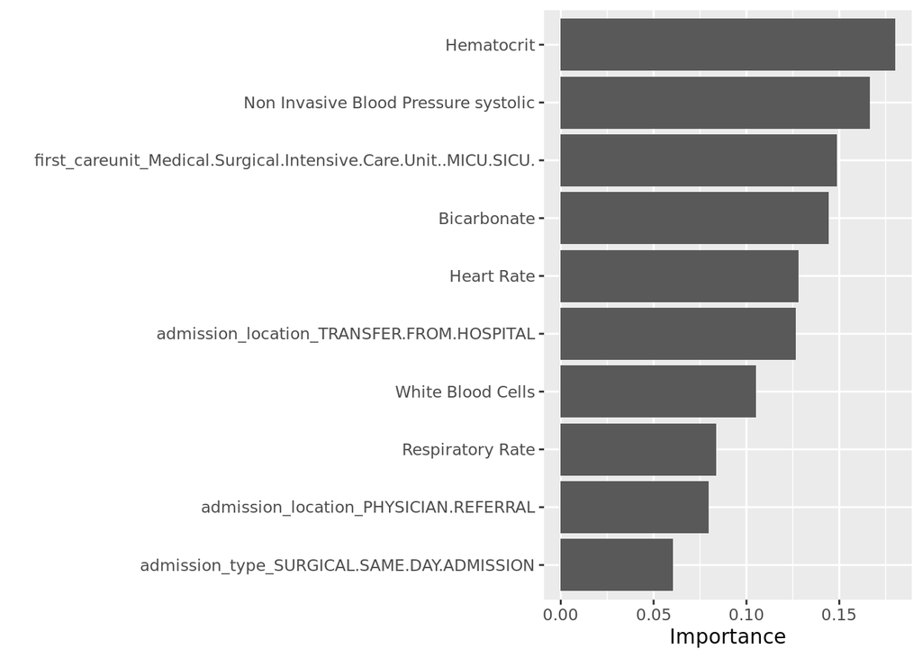

```r
final_logit_fit <- fit(final_logit_wf, data = mimic_train)
vip(final_logit_fit$fit$fit)
```

## How do the models compare in terms of performance and interpretability?

Answer: The performance comparison between models is achieved by comparing the accuracy and AUC of the predicted results, and models with higher accuracy and AUC generally perform better.The interpretability of a model is characterized by its results. Logistic regression model has higher interpretability when used for classification prediction, as they can directly output the relationship between features and prediction results. Complex models generally have poorer interpretability but better performance. In this work, the accuracy and AUC of random forest and neural network models are higher than logistic regreesion model.